# Logistic Regression - Predicting Diabetes Diagnosis

4/26/2020

Myles Lane

## Data Cleaning/Preparation

To prepare the data I imported the diabetes dataset and converting height and weight variables into SI measurements. Then using these, I calculated the BMI and added that variable to the dataset. I also created a categorical bmi variable by conditionally changing the numerical BMI variabel to “underweight”" for values under 18.5, “normal” for values between 18.5 and 25, “overweight” for values between 26 and 30, and “obese” for values greater than 30. I also recoded the insurance variable to categorical by changing values of 0,1 and 2 to “none”, “government”, and “private” respectively. Similarly, I recoded the smoking variable to categorical by changing values of 1,2, and 3 to “current”, “never” and “ex-smoker”.

```r
#Import Dataset
library(tidyverse)
library(dplyr)
library(Hmisc)
library(ggplot2)
setwd("/Users/myles/Downloads/")
diabetes <- read.csv("diabetes.csv")

#Create BMI variable
height.si <- diabetes$height * 0.0254
weight.si <- diabetes$weight * 0.453592
diabetes <- mutate(diabetes, BMI = weight.si/(height.si^2))

#Recode bmi, insurance and smoking variables
diabetes<- mutate(diabetes, bmi_categorized = cut(diabetes$BMI, breaks = c(0,18.5,25,30,Inf),labels = c("underweight","normal","overweight","obese")))

diabetes <- mutate(diabetes, insurance = ifelse(insurance==0, "none",
                                                ifelse(insurance==1, "government",
                                                ifelse(insurance==2, "private", NA))))
diabetes <- mutate(diabetes, smoking = ifelse(smoking==1, "current",
                                              ifelse(smoking==2, "never",
                                              ifelse(smoking==3, "ex-smoker", NA))))
```

## Exploratory Data Analysis

Within the dataset there are 403 obseravtions across 23 variables. The percentage of obese individuals is 38.3%. The percentage of females is 58.1%. The percentage of individuals that have diabetes is 15.4%. The average age is 47 and the average BMI is 28.8.

```r
describe(diabetes)
prop.table(table(diabetes$bmi_categorized))*100
prop.table(table(diabetes$gender))*100
prop.table(table(diabetes$dm))*100
mean(diabetes$age)
mean(diabetes$BMI, na.rm = TRUE)
```

## Data Visualization

Figure 1 shows a graph of the insurance types in the dataset. Government has the most observations at 147, followed by private at 139 and then no insuranceat 117. Figure 2 shows respondent smoknig frequency. People who have never smoked have the most observations at 223, followed by current smokers at 121 and then people who have stopped smoking at 59. Figure 3 shows a scatter plot of BMI by Cholesterol level. The variables appear to be loosely associated but the slope stays the same from left to right. Figure 4 shows a histogram of the ages within the dataset. There appears to be two peaks at ages 40 and 60. The overall curve of the graph seems to have a skew on the right side.

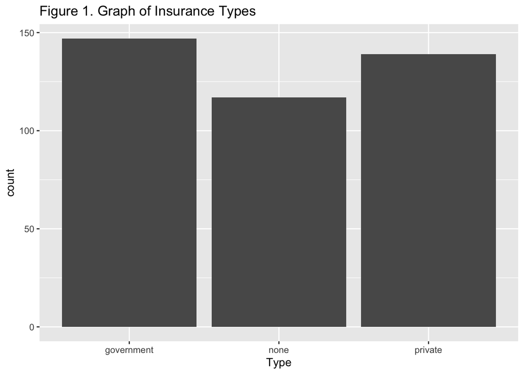

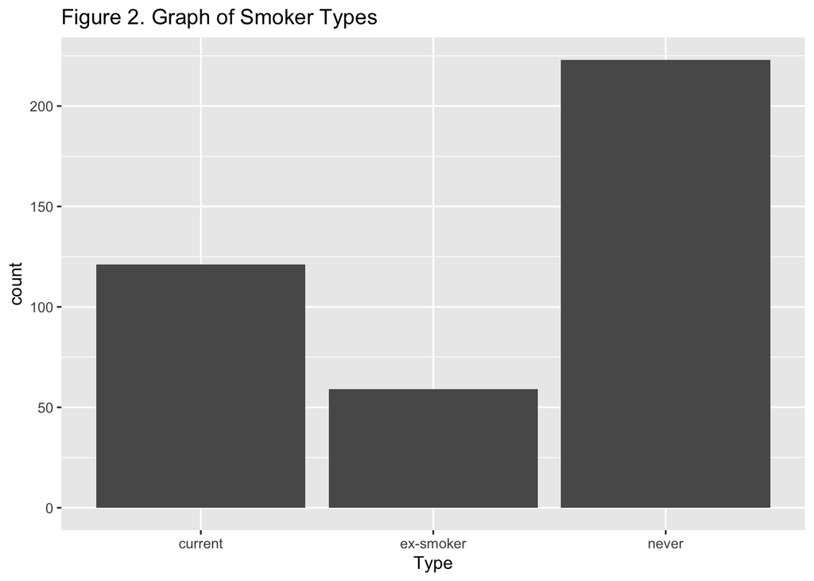

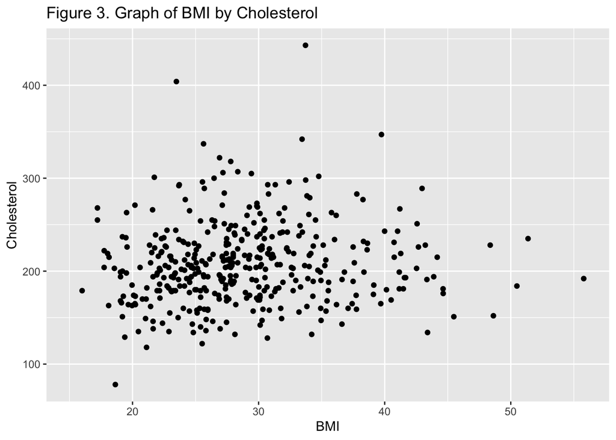

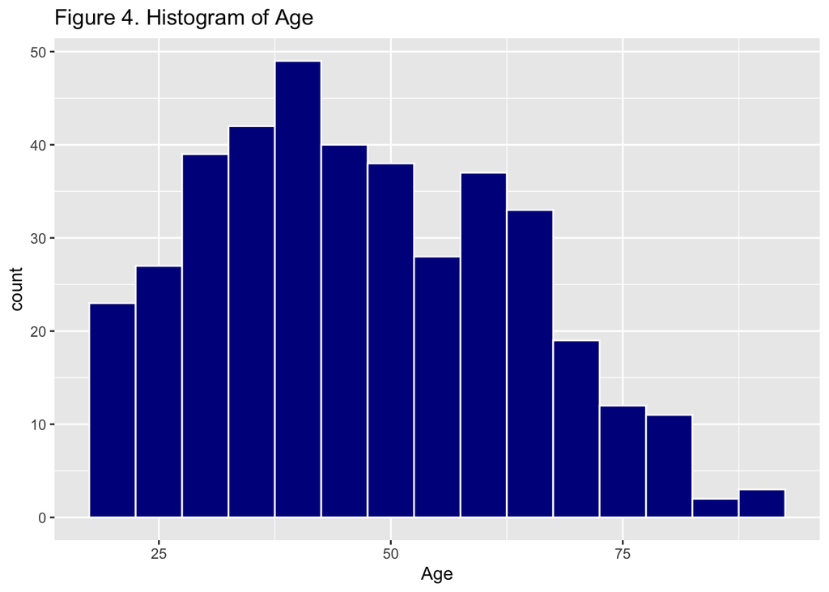

## Logistic Regression Results

**Age:** *A 1-year increase in age causes the log odds of having diabetes to increase by 0.055, holding other independent variables constant.*

**Gender:** *The log odds of having diabetes is 0.245 higher in males than in females.*

**BMI:** *A 1-unit increase in BMI causes the log odds of having diabetes to increase by 0.074.*

```r
#logistic regression code
model <- glm(dm ~ age + factor(gender) + BMI, data = diabetes, family = "binomial")
model
```